# Fourth Week: Hypothesis Testing

TIMSS Analysis

Mohammadmahdi Faryabi - STD-ID: 93101951

2018-03-09 02:57:49

# تمرین سری چهارم: چقدر ریاضی بلدیم و چرا؟

لطفا مقاله زیر را مطالعه بفرمایید.

[چرایی رتبه ضعیف ایران در آزمون تیمز](https://goo.gl/gX8DZc)

> با استفاده از داده های ارزیابی تیمز ۲۰۱۵ ادعاهای زیر را مورد ارزیابی قراردهید. برای هر سوال علاوه بر استدلال آماری که در غالب آزمون فرض تعریف می شود از تصویرسازی مناسب باهر دو ابزار ggplot2 و highcharter استفاده نمایید. به دلخواه به هفت گزاره از موارد زیر پاسخ دهید.

```r
library(readr)
library(dplyr)
```

```r
library(tidyr)
library(highcharter)
library(ggplot2)

tims_2015 <- read_rds('../timss15_grade_8/timss_2015.rds')
bcg <- read_rds('../timss15_grade_8/data/bcg.rds')
btm <- read_rds('../timss15_grade_8/data/btm.rds')
bts <- read_rds('../timss15_grade_8/data/bts.rds')
bsg <- read_rds('../timss15_grade_8/data/bsg.rds')
bsr <- read_rds('../timss15_grade_8/data/bsr.rds')
bst <- read_rds('../timss15_grade_8/data/bst.rds')
bsa <- read_rds('../timss15_grade_8/data/bsa.rds')
```

۱. میران رضایت معلمان در پیشرفت تحصیلی دانش آموزان موثر است.

> Sounds like teachers are more satisfied teaching to lower tier students than the smart talented ones!  
> the more satisfied a teacher is, the lower level his/her students are!  
> Low p-value for hypothesis test of irrelevancy of teacher’s satisfaction and student levels proves this point.

```r
################################################################################################################
# Q1

stud_teacher_country <- bst %>% select(idcntry, idtealin, idstud) # no unique needed.
stud_math_score <- bsa %>% select(idcntry, idstud, idschool, bsmmat01, bsmmat02, bsmmat03, bsmmat04, bsmmat05) %>%
  group_by(idcntry, idstud, idschool) %>% summarise(math_score = (bsmmat01+bsmmat02+bsmmat03+bsmmat04+bsmmat05)/5)
teacher_sat_inv_score <- btm %>% select(idcntry, idtealin, btbg10b)


q1_full_data <- full_join(stud_teacher_country, stud_math_score) %>% right_join(teacher_sat_inv_score)
aov(math_score~btbg10b, data = q1_full_data) %>% summary.aov()
```

```
##                 Df    Sum Sq Mean Sq F value Pr(>F)
## btbg10b          1 5.518e+06 5518024   484.7 <2e-16 ***
## Residuals   268131 3.053e+09   11385
## ---
## Signif. codes:  0 '***' 0.001 '**' 0.01 '*' 0.05 '.' 0.1 ' ' 1
## 17460 observations deleted due to missingness
```

```r
q1_full_data %>% select(teacher_satisfaction = btbg10b, math_score) %>% group_by(teacher_satisfaction) %>%
  summarise(mean_math_score = mean(math_score)) %>% hchart(type = 'line', hcaes(x = teacher_satisfaction, y = mean_math_score))
```

[interactive chart not shown]

۲. والدینی که تحصیلات بیشتری دارند دارای فرزندان موفق تری می باشند.

> The more educated the parents are, more educationally talented the child is! Low p-value for hypothesis test of irrelevancy of parent’s cumulative education level and student levels proves this point.

```r
################################################################################################################
# Q2

# bsa %>% select(idcntry, idstud, bsmmat01, bsmmat02, bsmmat03, bsmmat04, bsmmat05) %>% View()
# btm %>% select(idcntry, idtealin, btbg10a, btbg10b, btbg10c, btbg10d, btbg10e, btbg10f, btbg10g) %>%  View()

bsg %>% select(idcntry, idstud, bsbg07a, bsbg07b)%>% filter(bsbg07a != 8 & bsbg07b != 8) %>%
  mutate(parent_edu = bsbg07a+bsbg07b) %>%
  select(idcntry, idstud, parent_edu) -> parent_edu

full_join(parent_edu, stud_math_score) %>% .[complete.cases(.),]-> stud_parent
```

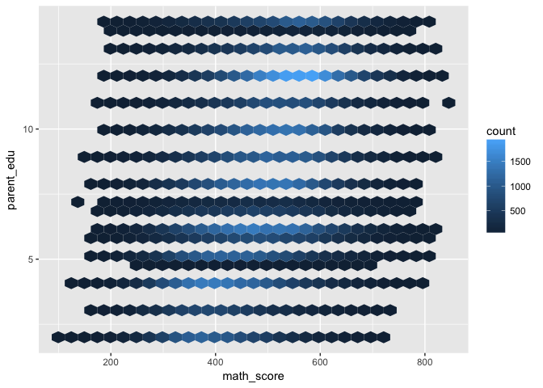

```r
stud_parent$math_score <- as.numeric(stud_parent$math_score)
ggplot(stud_parent, aes(x = math_score, y = parent_edu))+geom_hex()
```

```r
stud_parent %>% group_by(parent_edu) %>% summarise(mean_math_score = mean(math_score)) %>%
  hchart(type = 'line', hcaes(x = parent_edu, y = mean_math_score))
```

[interactive chart not shown]

```r
aov(math_score~parent_edu, stud_parent)->fit_q2
summary.aov(fit_q2)
```

```
##                 Df    Sum Sq   Mean Sq F value Pr(>F)
## parent_edu       1 2.799e+08 279854509   27876 <2e-16 ***
## Residuals   168494 1.692e+09     10039
## ---
## Signif. codes:  0 '***' 0.001 '**' 0.01 '*' 0.05 '.' 0.1 ' ' 1
```

۳. امکانات رفاهی در خانه موجب پیشرفت تحصیلی می گردد.

> in order to calculate a factor for home amenities, I’ve used the following factors:  
> * numbrt of books (as a number ranging from 0 to 4  
> * number of digital information devices (as a number ranging from 0 to 4)  
> * 11 factors mentioned in student question 6 (as a number ranging from 1 to 11)  
> then summed them up and calculated a numeric factor indicating home amenities level for student.  
> I’ve tried to prove that more home amnities a student has, better he/she performs in education.  
> the regression hypothesis test is proving this point but this test is based on an assumption that data is linear and distributed with not much chaotic variance. our data here are distributed variantly and therefore the statements may not be so accurate.

```r
################################################################################################################
# Q3

bsg %>% select(idcntry, idstud, book = bsbg04, comp = bsbg05, a = bsbg06a, b = bsbg06b, c = bsbg06c, d = bsbg06d,
                e = bsbg06e, f = bsbg06f, g = bsbg06g, h = bsbg06h, i = bsbg06i, j = bsbg06j, k = bsbg06k) %>%
  group_by(idcntry, idstud) %>% summarise(home_emnities = book+comp+a+b+c+d+e+f+g+h+i+j+k-13) %>%
  .[complete.cases(.),] -> student_home_amnities

full_join(stud_math_score, student_home_amnities) %>% .[complete.cases(.),] -> q3_full_data
```

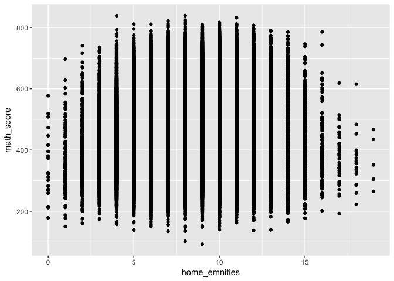

```r
q3_full_data %>% ggplot(aes(x = home_emnities, y = math_score)) + geom_point()
```

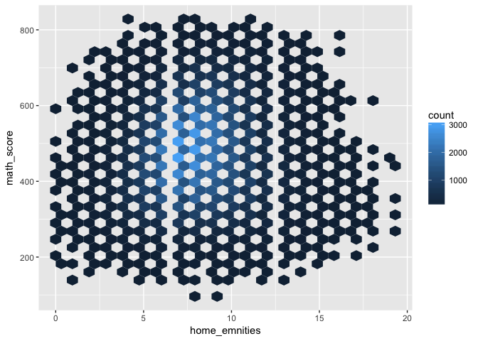

```r
q3_full_data %>% ggplot(aes(x = home_emnities, y = math_score)) + geom_hex()
```

```r
lm(math_score~home_emnities, data = q3_full_data) -> fit_q3
summary.lm(fit_q3)
```

```
##
## Call:
## lm(formula = math_score ~ home_emnities, data = q3_full_data)
##
## Residuals:
##     Min      1Q  Median      3Q     Max
## -387.68  -80.58   -1.14   77.78  374.68
##
## Coefficients:
##               Estimate Std. Error t value Pr(>|t|)
## (Intercept)   450.1561     0.9480  474.83   <2e-16 ***
## home_emnities   3.3255     0.1132   29.38   <2e-16 ***
## ---
## Signif. codes:  0 '***' 0.001 '**' 0.01 '*' 0.05 '.' 0.1 ' ' 1
##
## Residual standard error: 108.1 on 188497 degrees of freedom
## Multiple R-squared:  0.004558,   Adjusted R-squared:  0.004553
## F-statistic: 863.2 on 1 and 188497 DF,  p-value: < 2.2e-16
```

۴. محیط آرام مدرسه نقش مهمی در پیشرفت تحصیلی دارد.

```r
################################################################################################################
# Q4
```

۵. معلمان با تحصیلات بالاتر یا تجربه بیشتر دانش آموزان موفق تری تربیت می کنند.

> The more educated the teacher is, more educationally talented the students are!  
> Low p-value for hypothesis test of irrelevancy of teacher’s education level and student’s level proves this point.

```r
################################################################################################################
# Q5

btm %>% select(idcntry, idtealin, teacher_edu_level = btbg04, experience = btbg01) -> teacher_edu_level

full_join(stud_teacher_country, stud_math_score) %>% right_join(teacher_edu_level) %>% .[complete.cases(.),] -> q5_full_data
aov(math_score~experience*teacher_edu_level, data = q5_full_data) %>% summary.aov()
```

```
##                                  Df    Sum Sq   Mean Sq  F value  Pr(>F)
## experience                        1 4.094e+06   4093869   386.05 < 2e-16
## teacher_edu_level                 1 1.667e+08 166709854 15720.49 < 2e-16
## experience:teacher_edu_level      1 5.545e+05    554537    52.29 4.8e-13
## Residuals                    249350 2.644e+09     10605
##
## experience                   ***
## teacher_edu_level            ***
## experience:teacher_edu_level ***
## Residuals
## ---
## Signif. codes:  0 '***' 0.001 '**' 0.01 '*' 0.05 '.' 0.1 ' ' 1
```

```r
q5_full_data %>% group_by(teacher_edu_level) %>% summarise(mean_math_score = mean(math_score)) %>%
  hchart(type = 'line', hcaes(x = teacher_edu_level, y = mean_math_score))
```

[interactive chart not shown]

```r
q5_full_data %>% mutate(experience = (experience %/% 5) * 5) %>% group_by(experience) %>% summarise(mean_math_score = mean(math_score)) %>%
  hchart(type = 'line', hcaes(x = experience, y = mean_math_score))
```

[interactive chart not shown]

۶. پسران در کاربرد هندسه قوی تر هستند.

> the p-value for hypothesis test of irrelevancy of boys’ performance in applied geometry vs girls’ is high and therefore this statement can not be concluded from the test! the diagrams for boys’ vs girls’ performances also proves this.

```r
################################################################################################################
# Q6

tims_2015 %>%
  select(question, students_per_question_male,students_per_question_female, cognitive_domain, content_domain,
         correct_ratio_per_question_female, correct_ratio_per_question_male) %>%
  filter(cognitive_domain == 'Applying', content_domain == 'Geometry') %>% group_by(question) %>%
  mutate(female_cnt = students_per_question_female*correct_ratio_per_question_female,
         male_cnt = students_per_question_male*correct_ratio_per_question_male) %>%
  summarise(female = sum(female_cnt), male = sum(male_cnt)) %>% select(question, female, male) %>%
  tidyr::gather('male', 'female', key = 'gender', value = 'score') -> q6_full_data

t.test(score~gender, data = q6_full_data, alt = 'greater') # boys better than girls
```

```
##
##  Welch Two Sample t-test
##
## data:  score by gender
## t = -0.036586, df = 41.943, p-value = 0.5145
## alternative hypothesis: true difference in means is greater than 0
## 95 percent confidence interval:
##  -982.1704       Inf
## sample estimates:
## mean in group female   mean in group male
##             6128.091             6149.000
```

```r
t.test(score~gender, data = q6_full_data, alt = 'less') # girls better than boys
```

```
##
##  Welch Two Sample t-test
##
## data:  score by gender
## t = -0.036586, df = 41.943, p-value = 0.4855
## alternative hypothesis: true difference in means is less than 0
## 95 percent confidence interval:
##      -Inf 940.3522
## sample estimates:
## mean in group female   mean in group male
##             6128.091             6149.000
```

```r
t.test(score~gender, data = q6_full_data, alt = 'two.sided') # one is better than other
```

```
##
##  Welch Two Sample t-test
##
## data:  score by gender
## t = -0.036586, df = 41.943, p-value = 0.971
## alternative hypothesis: true difference in means is not equal to 0
## 95 percent confidence interval:
##  -1174.285  1132.466
## sample estimates:
## mean in group female   mean in group male
##             6128.091             6149.000
```

```r
q6_full_data %>% hchart(type = 'column', hcaes(group = gender, y = score))
```

[interactive chart not shown]

```r
q6_full_data %>% group_by(gender) %>% summarise(score = sum(score)) %>%
  hchart(type = 'column', hcaes(group = gender, y = score))
```

[interactive chart not shown]

۷. تغذیه دانش آموزان نقش اساسی در یادگیری آنها دارد.

> better breakfast means better performance. according to anova test results  
> but it is obvious that some students still perform good without breakfast.  
> maybe education is more important for them than breakfast? :p

```r
################################################################################################################
# Q7

bsg %>% select(idcntry, idstud, breakfast = bsbg12) %>% full_join(stud_math_score) %>%
  .[complete.cases(.),] -> q7_full_data
aov(math_score~breakfast, data = q7_full_data) -> fit_q7
summary.aov(fit_q7)
```

```
##                 Df    Sum Sq  Mean Sq F value Pr(>F)
## breakfast        1 3.265e+07 32653399    2940 <2e-16 ***
## Residuals   276078 3.066e+09    11105
## ---
## Signif. codes:  0 '***' 0.001 '**' 0.01 '*' 0.05 '.' 0.1 ' ' 1
```

```r
q7_full_data %>% group_by(breakfast) %>% summarise(mean_math_score = mean(math_score)) %>%
  hchart(type = 'line', hcaes(x = breakfast, y = mean_math_score))
```

[interactive chart not shown]

۸. مدارس با امکانات بیشتر دارای عملکرد بهتری می باشند.

> better school facilities means better performance. according to anova test results  
> mean poin of distribution is moving up and variance is decreasing as school facility levels go up; accorfing to plots.

```r
################################################################################################################
# Q8

bcg %>% select(idcntry, idschool, bcbg08a:bcbg13ce) %>% mutate(bcbg08b = 3 - bcbg08a) %>%
  mutate(bcbg08b = ifelse(is.na(bcbg08b), 0, bcbg08b)) %>% mutate(bcbg12ab = ifelse(is.na(bcbg12ab), 0, bcbg12ab)) %>%
  mutate(bcbg12aa = ifelse(is.na(bcbg12aa), 0, bcbg12aa)) %>%
  mutate(school_facil = (bcbg08a*5+bcbg08b+bcbg09a+bcbg09b+bcbg10*5+bcbg11a*5+bcbg11b+bcbg12*5+bcbg12aa+bcbg12ab+bcbg12ba+
                           bcbg12bb+bcbg13aa+bcbg13ab+bcbg13ac+bcbg13ad+bcbg13ae+bcbg13af+bcbg13ag+bcbg13ah+
                           bcbg13ai+bcbg13ba+bcbg13bb+bcbg13bc+bcbg13bd+bcbg13be+bcbg13ca+bcbg13cb+bcbg13cc+
                           bcbg13cd+bcbg13cd)) %>% select(idcntry, idschool, school_facil) %>%
  mutate(school_facil = round(school_facil, digits = -1)) %>% .[complete.cases(.),] %>%
  full_join(stud_math_score) %>% .[complete.cases(.),] -> q9_full_data
aov(math_score~school_facil, data = q9_full_data) %>% summary.aov()
```

```
##                  Df    Sum Sq  Mean Sq F value Pr(>F)
## school_facil      1 1.840e+07 18402710    1769 <2e-16 ***
## Residuals    145925 1.518e+09    10401
## ---
## Signif. codes:  0 '***' 0.001 '**' 0.01 '*' 0.05 '.' 0.1 ' ' 1
```

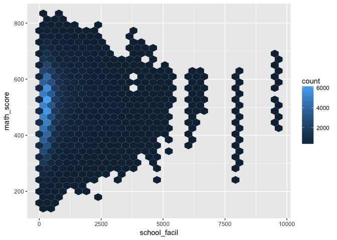

```r
q9_full_data %>% ggplot(aes(x = school_facil, y = math_score)) + geom_hex()
```

۹. علت افت تحصیلی عدم مشارکت در کلاس است.

> Academic failure should be measured over time!  
> these question implies that we should test the hypothesis that student academic performance is not related to his/her presense in class and prove its wrong.

```r
################################################################################################################
# Q9

bsg %>% select(idcntry, idstud, presence_level = bsbg11) %>% full_join(stud_math_score) %>%
  .[complete.cases(.),] -> q9_data
aov(math_score~presence_level, data = q9_data) -> fit_q9
summary.aov(fit_q9)
```

```
##                    Df    Sum Sq   Mean Sq F value Pr(>F)
## presence_level      1 2.648e+08 264849314   25650 <2e-16 ***
## Residuals      264983 2.736e+09     10326
## ---
## Signif. codes:  0 '***' 0.001 '**' 0.01 '*' 0.05 '.' 0.1 ' ' 1
```

```r
q9_data %>% group_by(presence_level) %>% summarise(mean_math_score = mean(math_score)) %>%
  hchart(type = 'line', hcaes(x = presence_level, y = mean_math_score))
```

[interactive chart not shown]

۱۰. دانش آموزان ایرانی در استدلال قوی تر از کاربرد هستند.

```r
################################################################################################################
# Q10
```

سه گزاره جالب کشف کنید و ادعای خود را ثابت نمایید.

> immigrant students or those who has born in a foreign country perform better than local born students.

```r
################################################################################################################
# Q11-1

bsg %>% select(idcntry, idstud, abroad = bsbg10a) %>% full_join(stud_math_score) %>% .[complete.cases(.),] -> q11_1_data
t.test(math_score~abroad, data = q11_1_data)
```

```
##
##  Welch Two Sample t-test
##
## data:  math_score by abroad
## t = -33.437, df = 39568, p-value < 2.2e-16
## alternative hypothesis: true difference in means is not equal to 0
## 95 percent confidence interval:
##  -21.78009 -19.36806
## sample estimates:
## mean in group 1 mean in group 2
##        475.2210        495.7951
```

```r
q11_1_data %>% group_by(abroad) %>% summarise(mean_score = mean(math_score)) %>%
  hchart(type = 'column', hcaes(x = abroad, y = mean_score))
```

[interactive chart not shown]

> speaking mother tongue is better for good education

```r
################################################################################################################
# Q11-2

bsg %>% select(idcntry, idstud, home_lang = bsbg03) %>% full_join(stud_math_score) %>% .[complete.cases(.),] -> q11_2_data
aov(math_score~home_lang, data = q11_2_data) %>% summary.aov()
```

```
##                 Df    Sum Sq   Mean Sq F value Pr(>F)
## home_lang        1 1.247e+08 124734246   11575 <2e-16 ***
## Residuals   276740 2.982e+09     10776
## ---
## Signif. codes:  0 '***' 0.001 '**' 0.01 '*' 0.05 '.' 0.1 ' ' 1
```

```r
q11_2_data %>% group_by(home_lang) %>% summarise(mean_score = mean(math_score)) %>%
  hchart(type = 'column', hcaes(x = home_lang, y = mean_score))
```

[interactive chart not shown]

> having many electronic it devices has a bad impact but in general it and technology can be a help to education

```r
################################################################################################################
# Q11-3

bsg %>% select(idcntry, idstud, devices = bsbg05) %>% full_join(stud_math_score) %>% .[complete.cases(.),] -> q11_3_data
aov(math_score~devices, data = q11_3_data) %>% summary.aov()
```

```
##                 Df    Sum Sq   Mean Sq F value Pr(>F)
## devices          1 1.949e+08 194893883   18558 <2e-16 ***
## Residuals   276057 2.899e+09     10502
## ---
## Signif. codes:  0 '***' 0.001 '**' 0.01 '*' 0.05 '.' 0.1 ' ' 1
```

```r
q11_3_data %>% group_by(devices) %>% summarise(mean_score = mean(math_score)) %>%
  hchart(type = 'column', hcaes(x = devices, y = mean_score))
```

[interactive chart not shown]